# A3: SPL Library Checkouts

### Introduction

The data set comes from the SPL checkouts from 2017-2023 with monthly updates and still is ongoing. I am choosing to analyze information surrounding number of checkouts, checkout year, material type, and title. Specifically, I am interested in how the average number of checkouts varies between the years, whether this number flucuates or remains relatively stable. I am also interested in how the publication date and title impacts the amount of checkouts because I want to know if readers continue to check out books of the same series or are less motivated as the series goes on. Last thing I’m interested in is seeing how the different material types are distributed in terms of the number of checkouts seeing as our society is moving towards increased computerization of everyday things.

### Summary Information

Among some of the values I calculated were average number of times each library item was checked out this ranged from 10 checkouts to nearly 5,000. I also evaluated which month had the month and least checkouts for a book called Catching Fire, which is related to the one of the graphs that I will soon be introducing, but the checkouts also include the movie adaptation therefore the checkout numbers will be much greater than the one I observed. The month with the highest number of checkouts is June with 4,903 and the least is 10, which is actually the lowest limit these items could be checked out and still considered in the data, so there is a tie across all months. I answered similar questions regarding ebooks, but instead of months I calculated what year had the most and least checkouts. The most amount of ebook checkouts came from just last year in 2022 and the lowest again was 10 and difficult to distinguish between the months.

### The Dataset

- Who collected/published the data?
- What are the parameters of the data (dates, number of checkouts, kinds of books, etc.)?
- How was the data collected or generated?
- Why was the data collected?
- What, if any, ethical questions do you need to consider when working with this data?
- What are possible limitations or problems with this data? (at least 200 words)

The data set was collected and published by the Seattle Public Library. It holds 12 columns of variables that include usage class, checkout type, material type, checkout year, checkout month, number of checkouts, title, ISBN, creator, subjects, publisher, and publication years, of which there are 816,354 rows of observations within the last 6 years spanning from 2017-2023. The data was generated by recording checkout information for each book, audiobook, ebook, etc. every month of each year. As part of the Seattle Open Data Program, the data is collected to accomplish some of the goals such as increasing transparency and promoting research. The SPL face some ethical concerns regarding the homeless population in King County that may want access to the library’s services but are not granted them. Library checkouts are not homeless friendly, to sign up for a library card requires entering a permanent address and they cannot afford computers/technologies to checkout digital books online either. Other limitations to the data to consider are some books have more copies than other while some have less therefore some have longer wait times, which could lead to less checkouts. The data also do not tell us if renewals of a previous checkout count as another checkout or just one, or what happens when people lose the books and pay a fine instead.

### First Trends Over Time Chart

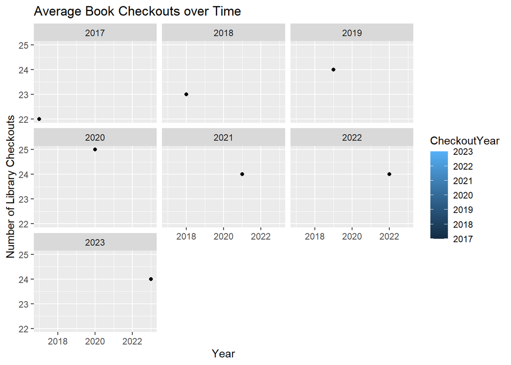

### Second Trends Over Time Chart

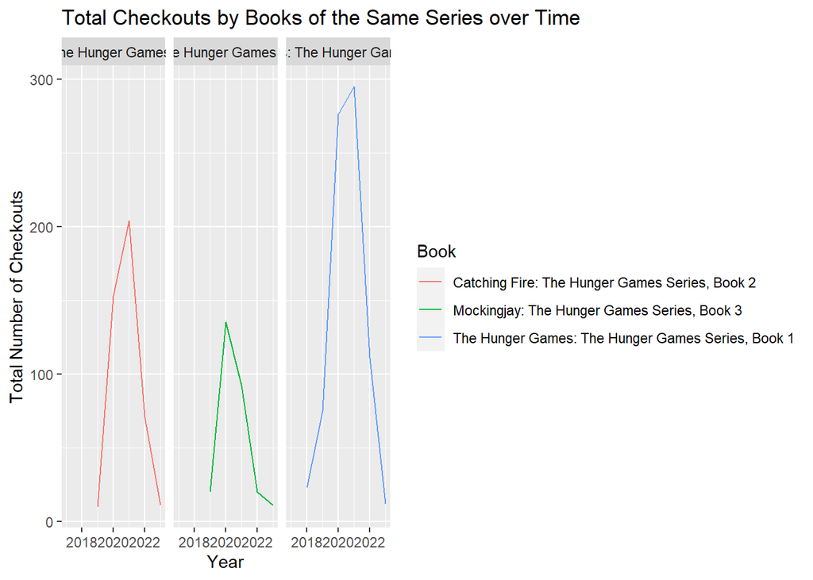

In the second trends over time graph, I compared three different books from the same series and author to see if the order would impact how frequently it was checked out as well as answering a question I had about how dedicated readers are to a book series. As you can see, the results were nothing unexpected, they all followed a similar trend pattern reaching their highest checkout numbers in 2020-2021, the first book had the highest number of checkouts, which decreased after each book. Publication date/how old the book is does not seem to matter in terms of its popularity as the oldest book still has many checkouts within the last couple of years. I did however think that the second and the third book would have a similar number of checkouts and the disparity shocked me a little because I have read this books series before and the second book ends somewhat on a cliffhanger and I assumed that readers would be more curious to figure out the issue would be resolved.

### Your Choice

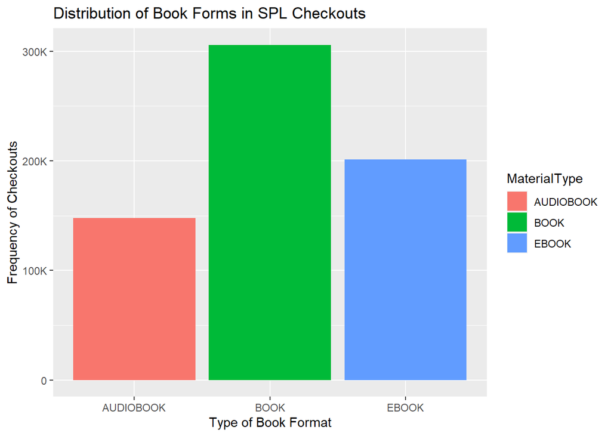

In the third visualization, I chose to make a bar chart in order to see the distribution, whether it was even or skewed a certain direction between the material type of the book and how often it was being checked out. Back then there were only physical books to select from in libraries for borrowing, but now books are offered in other formats that include audiobooks and ebooks, which are both appealing for its convenience of being able to access them virtually anywhere from a phone or tablet. It is because of these reasons that surprise me when my findings show that regular books are still the most popular and most checked out material type considering my own personal experience having grown up with printed books but primarily using ebooks/textbooks whether its for school or leisure. According the Seattle Public Library’s database, books have over 100,000 more checkouts than ebooks and the double the amount of audiobooks checked out.